# Analysis of Prosper Loans

## by ODENIYI, Oluwasegun Olawale

## Investigation Overview

In this investigation, I wanted spot relevant trends and insights, and also to look at the factors that can predict the interest rate on loans; and factors that can predict a loan's outcome.

## Dataset Overview

> The dataset consisted of 113937 records of Proper loans generated between the year 2005 - 2014. several variables such as; each loan's listing and closing date, interest rate, loan original amount, prosper rating, loan status, income range, employment status describes each loan. 327 datapoints having anomalous monthly income values were removed from the dataset.

### Distribution of Loan Amount

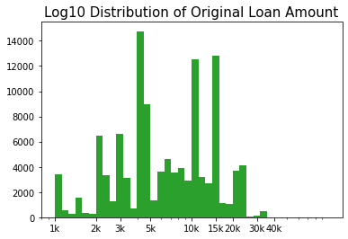

### Distribution of Interest Rate

The borrower's rate show an almost normal distribution with a steady increase in the interest rate from about 5-20% with a lot of loans falling in this region. There is an observed fall in the frequency of loans in the upper range of interest rate, although, there appears to be a spike in the frequency of loans a little above the 35% interest rate.

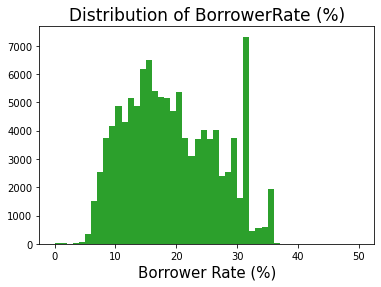

### Distribution of Loan Status

A large percentage (~50%) of the loans are still active (current), but we can see that more than 10% of the entire loans listed over the years have been classified as being **chargedoff**. We also see that 16.6% of the loans ever listed are bad loans. This proportion of chargedoff loans is significant.

```
Percentage of Chargedoff loans: 10.5%
Total percentage of Bad loans: 16.6%
```

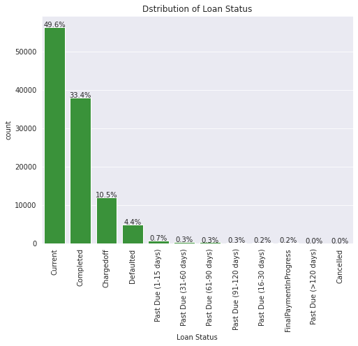

### How much loan is listed by yearly?

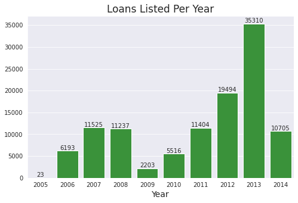

### Quantity of loans listed across quarters of the years

We have given out more loans in the first quarter of 2014 compared to that of the previous years, with a total of 12,000 loans originated. We can also observe an upward trend in the number of loans originated across Q2-Q4 of year 2013, and preceeding years. With this, we can easily predict an upward trend for the year 2014.

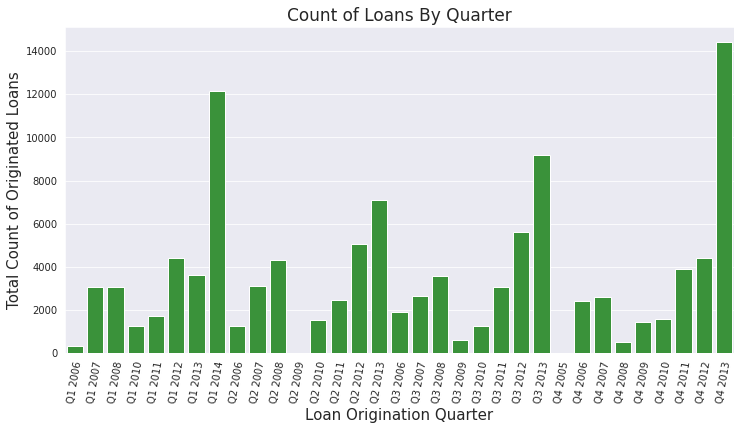

### Loan Amount vs. Interest Rate

The scatterplot of loan amount and Interest rate shows a somewhat curved, but negative relationship between the Loan original amount and Interest rate. Larger loan amounts are seen to have lower interest rate, while lower loan amounts have higher interest rates. We can also see that most of the loans originated are between 0-$15,000 range, and are clustered between around the 5% to 35% interest rate.

```
loan clean.shape= (113610, 84)
loan_clean_sample.shape= (11000, 84)
```

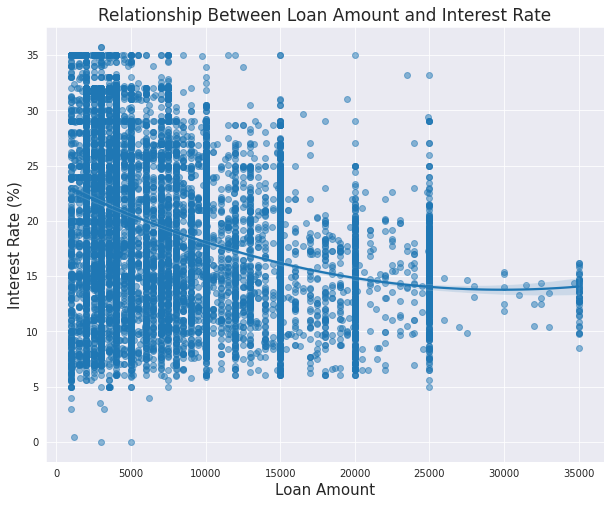

### Loan Outcome vs. Interest Rate (%)

The median of the all bad loans(defaulted, chargedoff, and pastdue) are higher than those of either the completed or current loans. We can also see that most of the completed loans have lower interest rates, compared to the defaulted and chargedoff loans. This suggests that a loan is likely to turn out bad if the interest rate is on the high side.

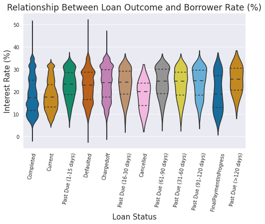

### How successful is the Prosper Rating in preventing Bad loans?

across all the seven possible ratings, **completed loans** take the highest count. However surprising is the fact that loans rated **D** appear to have the highest count of **completed and chargedoff loans**. We can also see a relatively high number of **chargedoff** loans across all ratings, which reduces significantly moving from **D (highest chargedoff loans)** to **AA** loans. Defaullted, Cancelled and Past due loans also reduce as the Prosper rating increases

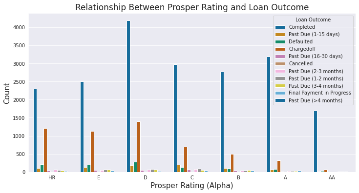

### Loan Outcome by year

[figure not shown]

### Loan Amount across interest rate and monthly income

Majority of the loans given to people who earn less than $10000 are on the lower end of the loan amount, and they are the ones who generally repay more (they get higher interest rates). This relationship may explain why there are more bad loans as interest rate increases.

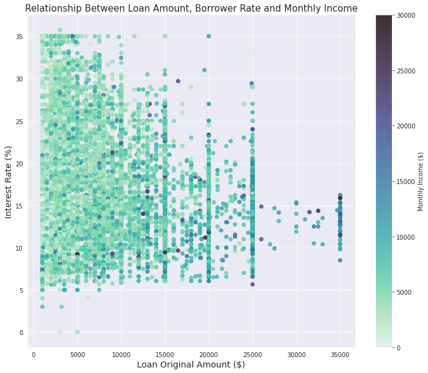

# Thanks for your Attention 🙂